# Projekt 1.0

JA

10 marca 2018

### Wprowadznie

Tematem projektu jest zbadanie mocy testów normalności rozkładu w przypadku, gdy dane pochodzą z rozkładu t-Studenta. Analiza będzie polegała na wyznaczeniu ramek danych zawierających wartości mocy testów dla poszczególnych przypadków uwzględniających zmiane:  
- długości próby,  
- ilości stopni swobody w rozkładzie t,  
- poziomu istotności  
oraz przedstawienie wyników na wykresach.

W analizie wykorzystane zostaną 3 testy: Shapiro-Wilka, Kołmogorowa-Smirnowa i Jarque-Bera.

Test Shapiro-Wilka: *shapiro.test(x)* Jeden z najbardziej popularnych testów standardowych, wykorzystywany do testowania normalności danych. Analiza porównawcza przy użyciu metod Monte-Carlo wykazała, że test Shapiro-Wilka ma największa moc spośród testów badających normalność. Hipotezą zerowymi w tym teście jest stwierdzenie, że próba pochodzi z rozkładu normalnego

Test Kołmogorowa-Smirnowa: *ks.test(x, y)* Test zgodności dla rozkładów ciągłych. Pozwala na badanie zgodności rozkładu cechy ‘x’ z wybranym rozkładem teoretycznym ‘y’, (w tym przypadku jest to rozkład normalny - pnorm) lub też na badanie równości rozkładów dwóch cech. W teście Kołmogorowa hipotezą zerową jest stwierdzenie, że dwie porównywane pórby mają takis am rozkład.

Test Jarque-Bera: *jarque.bera.test(x)* Testuje wartość normalności dla ‘x’ przy użyciu statystyki Jarque-Bera. Test ten jest statystyką wspólną wykorzystującą współczynniki skośności i kurtozy. Zwykle wykorzystywany jest do dużych zastawów danych, gdyż inne testy normalności nie są wiarygodne przy testowaniu większych prób (np. Shapiro-Wilka dla ilości danych powyżej 2000). Hipotezą zerową w tym teście jest stwierdzenie, że próba pochodzi z rozkładu normalnego.

W projekcie użyte zostaną 3 wektory - długości próby (lenght), ilości stopni swobody (df) oraz pozimu istotności (alpha). Długość próby będzie miała zakres od 12 do 22 i będzie zwiększana o 2, stopnie swobody będą z zakresu od 1 do 11, natomiast do poziomu istotności zostaną przypisane typowe wartości używane przy analizie normalności - (0.02, 0.05, 0.1, 0.2).

Obliczenie wykonane w poniżej analizy będą miały na celu stwierdzneie prawidłowości następujących hipotez:

*W zależności od zmiany długości próby:*  
H0: wraz ze zwiększaniem długości próby rośnie moc testu  
H1: wraz ze zwiększaniem długości próby maleje moc testu

*W zależności od zmiany ilości stopni swobody:*  
H0: wraz ze zwiększaniem ilosci stopni swobody maleje moc testu  
H1: wraz ze zwiększaniem ilości stopni swobody rośnie moc testu

*W zależnosci od zmiany poziomu istotności:*  
H0: wraz ze zwiekszaniem poziomu istotności rośnie moc testu  
H1: wraz ze zwiekszaniem poziomu istotności maleje moc testu

We wszystich przypadkach prawidłowym wynikiem powinien być brak podstaw do odrzucenia hipotez zerowych.

### Wizualizacja

```r
#załadowanie bibliotek
library(dplyr)
library(tidyr)
```

```r
library(ggplot2)
library(tseries)
```

Wprowadzenie wartości do poszczególnych zmiennych

```r
#ilość symulacji
N <- 1000
#stopnie swobody
dfs <- seq(1, 11, by = 1)
#poziomy istotności
alphas <- c(.02, .05, .1, .2)
#długość próby
lengths <- seq(12, 22, by = 2)
```

Następnie za pomoca funkcji **expand.grid** tworzę ramkę danych wszystkich kombinacji o nazwie ‘params’ z każdą możliwą trójką z tych wartości.

```r
params <- expand.grid(df = dfs, alpha = alphas, length = lengths)
```

Dla każdej trójki danych z pomocą odpowiedniej funkcji (shapiro.test, ks.test lub jarque.bera.test) obliczana jest moc testów i za pomocą funkcji *sapply* dołączana do wektora *powers* Najpierw dla testu Shapiro-Wilka.

```r
set.seed(20)
powers <- sapply(1:nrow(params),
                 function(i){
                   df <- params[i, 1]
                   alpha <- params[i, 2]
                   n <- params[i, 3]
                   p_vector <- sapply(rep(df, N), function(x){
                     my_sample <- rt(n, df)
                     shapiro.test(my_sample)$p.value
                   })
                   mean(p_vector < alpha)
                 })
```

Tworzenie ramki danych dla wyników testu Shapiro-Wilka:

```r
shapiro_df <- bind_cols(params, power = powers)
```

Tworzenie 4 wykresów dla każdego z podanych na początku przedziałów istotności (alpha). Na osi poziomej X znajduje się ilość stopni swobody (df), a na osi pionowej Y moc testu (power). Poszczególne długości próby (length) zostały zilustrowane za pomocą kolorowych linii.

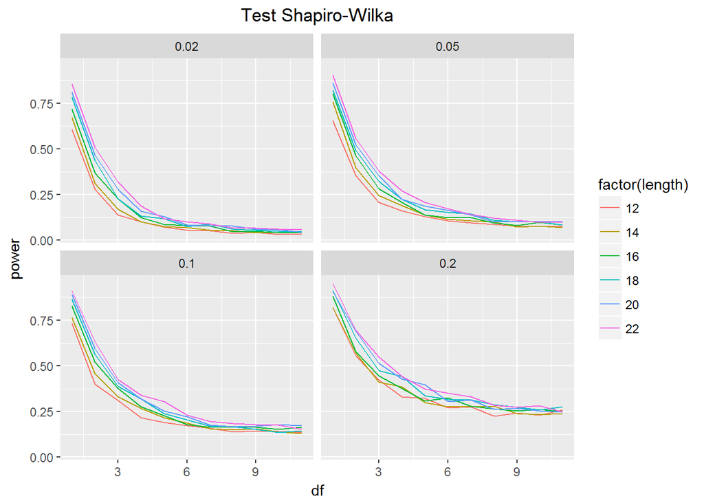

Powtarzam 3 ostatnie operacje dla pozostałych 2 testów.

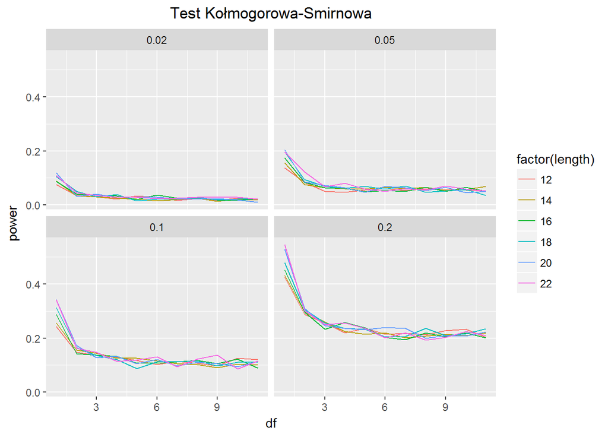

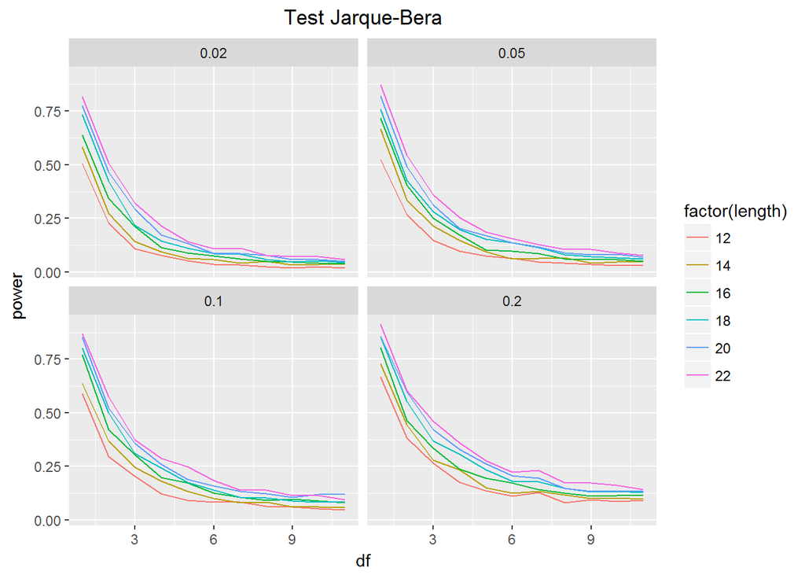

Wykres pokazujący jak zmieniają się moce testów w zależności od ilości stopni swobody, dla poziomu istotności równego 5% i długości próby równej 16.

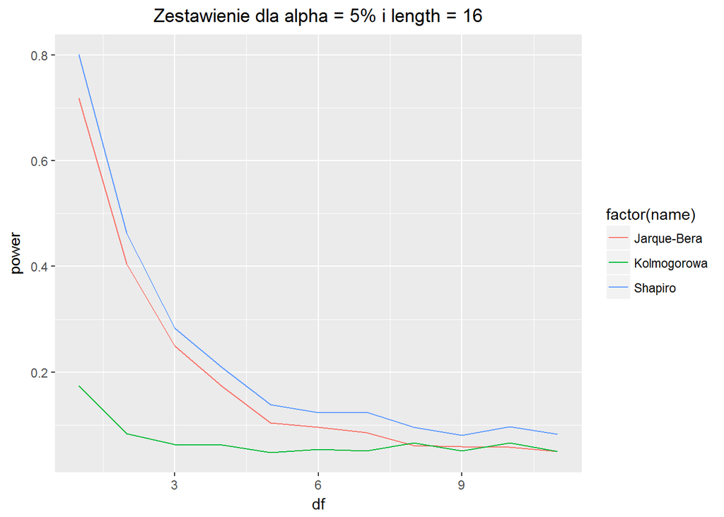

Wykres pokazujący jak zmieniają się moce testów w zależności od ilości stopni swobody, dla poziomu istotności równego 10% i długości próby równej 18.

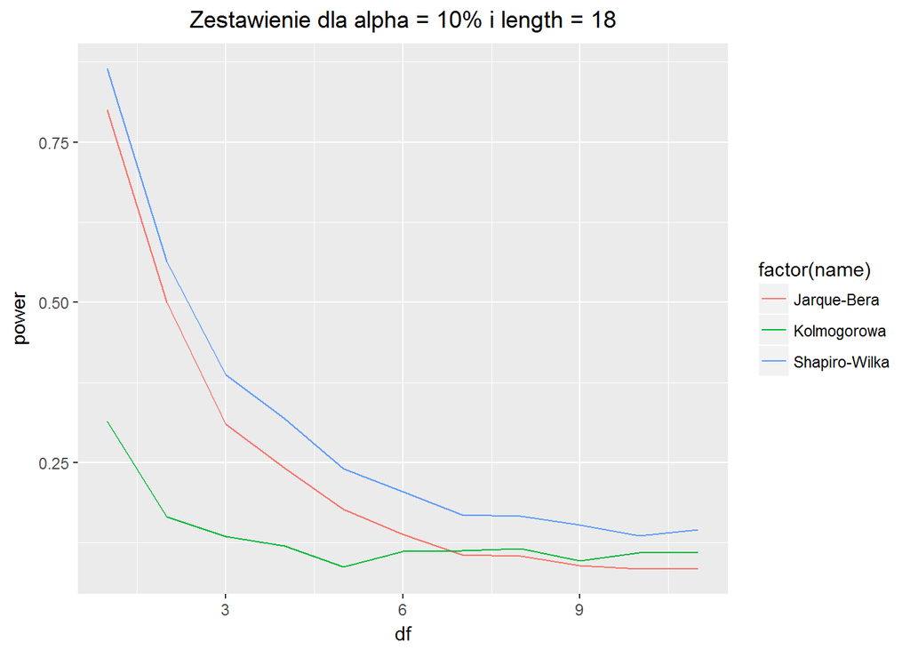

### Interpretacja

Po przeprowadzaniu powyższych wizualizacji można zauważyć, że we wszystkich trzech rozważanych przypadkach nie ma podstaw do odrzucenia hipotez zerowych.  
Oznacza to, że długość próby (length) istotnie wpływa na moc testu i wraz z jej wzrostem rośnie moc testu. Ilość stopni swobody (df) ma również istotny wpływ na moc testu i wraz z ich zwięszaniem moc znacznie spada. Moc testu zwiększa się wraz ze zwiększaniem poziomu istotności (alpha).  
Testy Shapiro-Wilka i Jarque-Bera lepiej interpretują zmianę mocy testu w zależności od długości próby. W teście Kołmogorowa-Smirnowa linie mocno się na siebie nakładają. Dla wszystskich z czterech podanych wartości alpha moc testu szybko spada wraz ze wzrostem ilości stopni swobody.  
We wszystkich trzech testach dla poziomu istotności 2% i dla 10 stopni swobody moc przyjmuje już wartość bliska 0%.

Na ostatnich dwóch wykresach wyraźnie widać, że test Shapiro-Wilka ma największą moc spośód badanych testów co pokrywa się z wynikami analizy porównawczej przy użyciu metod Monte-Carlo. Natomiast najmniejszym wskaźnikiem mocy cechuje się test Kołmogorowa-Smirnowa.

Na analizę mogą mieć wpływ następujące uproszczenia:  
- małe długości badanych prób,  
- liczba symulacji - 1000 wydaję się za mała, ale zwiększenie jej wiąże się ze znacznym wydłużeniem oczekiwania na wyniki,  
- uproszczone porównanie ze sobą mocy trzech testów może wpłynąć na wiarygodność.